# Bolsa

Grupo Bolsa

2022-12-01

## Relatório da Bolsa de Valores do Brasil

Este relatório tem como objetivo analisar cinco ações diferentes da Bolsa de Valores do Brasil(B3). O grupo responsável por esta análise é composto pelos seguintes integrantes:

- Airton Cândido;
- Thiago Lotufo;
- Wanderson Vitorino;
- Yuri Corrêa.

## Ações analisadas

As ações analisadas serão:

- EGIE3;
- GOLL4;
- PRIO3;
- GGBR4;
- MGLU3.

## Análise a ser realizada

A análise realizada será baseada no fechamento do dia de cada uma das ações, no período de de `2018` até `2022`.

Os cálculos são:

- Média;
- Mediana;
- Valor mínimo;
- Valor máximo;

## Análise final

### Cálculos de ações

| Índices | EGIE3 | GOLL4 | PRIO3 | GGBR4 | MGLU3 |
| --- | --- | --- | --- | --- | --- |
| Media | 39.81513 | 20.54961 | 11.37499 | 20.60287 | 10.6743 |
| Mediana | 40.92000 | 19.56000 | 7.18200 | 18.27000 | 7.0000 |
| Valor máximo | 54.10000 | 43.79000 | 38.50000 | 37.65000 | 27.4500 |
| Valor mínimo | 26.73600 | 5.60000 | 1.01860 | 8.64000 | 2.1300 |

# Melhores dias de compra de ações

## MGLU3

O melhor dia de compra das ações do Magalu foi 2022-07-04 no valor de R$ 2.13

## EGIE3

O melhor dia de compra das ações da Egiee foi 2018-06-21 no valor de R$ 26.736

## GOLL4

O melhor dia de compra das ações da Gol foi 2020-03-18 no valor de R$ 5.6

## PRIO3

O melhor dia de compra das ações da PetroRio foi 2018-04-09 no valor de R$ 1.0186

## GGBR4

O melhor dia de compra das ações da Gerdau foi 2020-03-23 no valor de R$ 8.64

## Informações gráficas

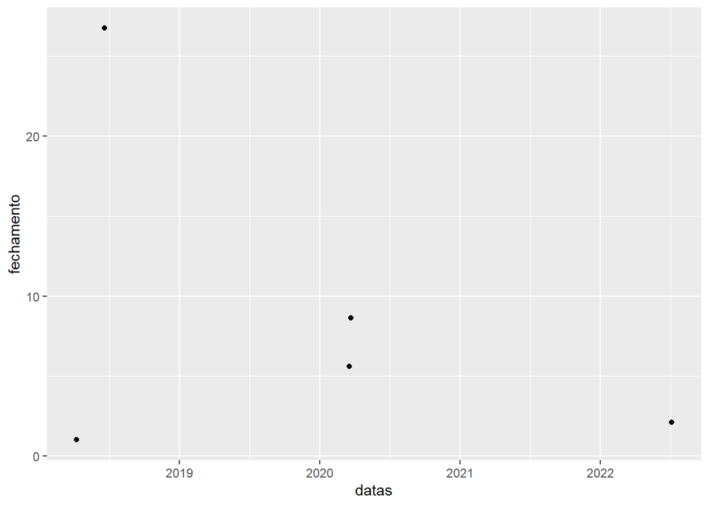

```r
ggplot(tabela, aes(x = datas, y = fechamento))+
  geom_point()
```

# Melhores dias de venda de ações

## Informações gráficas

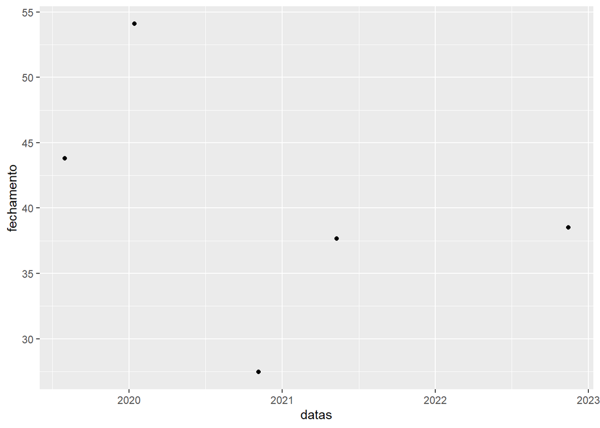

```r
ggplot(tabela, aes(x = datas, y = fechamento))+
  geom_point()
```